# Analytics I: Principles and Applications

KM Purcell

September 5, 2015

# Introductions

# About Me

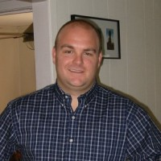

My [info](http://kevin-purcell.com)

# Background

- Currently: Data Science Director, WildFig
- Research Assiociate: National Marine Fishery Service
- Postdoctoral Fellow: Duke Univeristy, Quantitive Ecology
- Postdoctoral Fellow: NDSU, Molecular Ecology/Applied Genetics

# Class Background

- Introductions, affiliations, background

# Survey Questions

# Methods & Tools

- literate programming
- VCS, git?
- Reproducible research
- Statistical programming? R?
- GUI tools?

# Data management

- Experience with data management and products?
- DBMS, interaction, creation
- statistical programming: R?
- Experience interacting with data

# Data Analysis

- Statistical background
- Real-world applications
- `lm()`, `glm()`, `glmm()`, `gam()`
- ordination, CART, LDA, Bayesian, SVM,
- Graph theory, ANN,

# Data Visualization & Reporting

- E. Tufte
- Plot.ly, rCharts, D3.js,
- Grammer of Graphics?

# ANLY 500

# Course Overview

- Introduction to the main concepts and tools of analtyics/data science.
- Research methods: reproducible research, literate programming, DevOps
- Data Management: query and reporting, cleaning and QA/QC, relational databases
- Statistical programming, data mining introduction, statistical analysis of databases.

# Course Organization

- Analytics/Data Science Background
- Stat Programming, Research Methods & R Introduction
- Data Management
- Modeling
- Data Visualization
- Application

# Analytics/Data Science

# Data Science

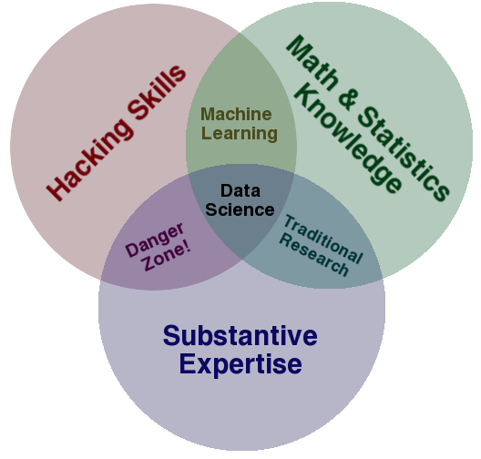

# Data Science

- **hacking** solution to [polygot programming](http://deanwampler.github.io/polyglotprogramming/)
- **stats** essential to derive the “signal from the noise”[*](http://www.amazon.com/The-Signal-Noise-Predictions-Fail-but/dp/0143125087)
- **Domain Knowledge** the crucial filter to end-users

# Data Science

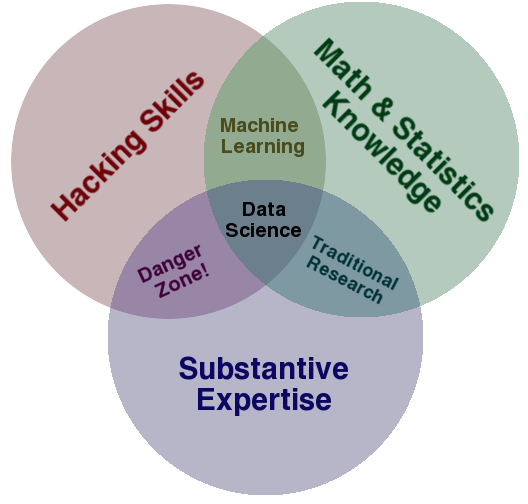

- STRATA 2014 Salary Survey [*](http://www.oreilly.com/data/free/files/2014-data-science-salary-survey.pdf)

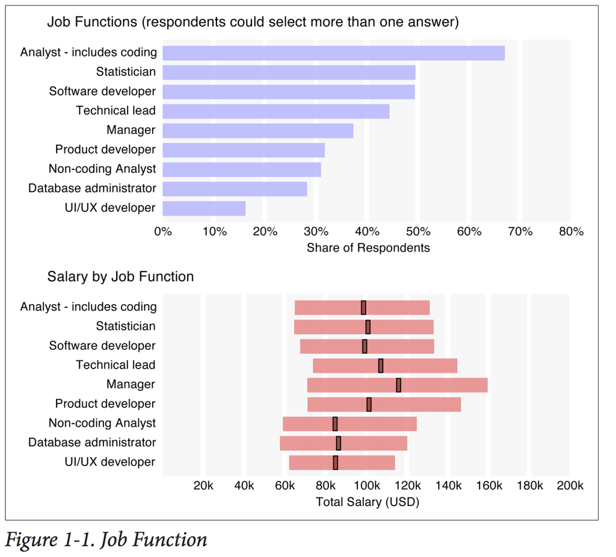

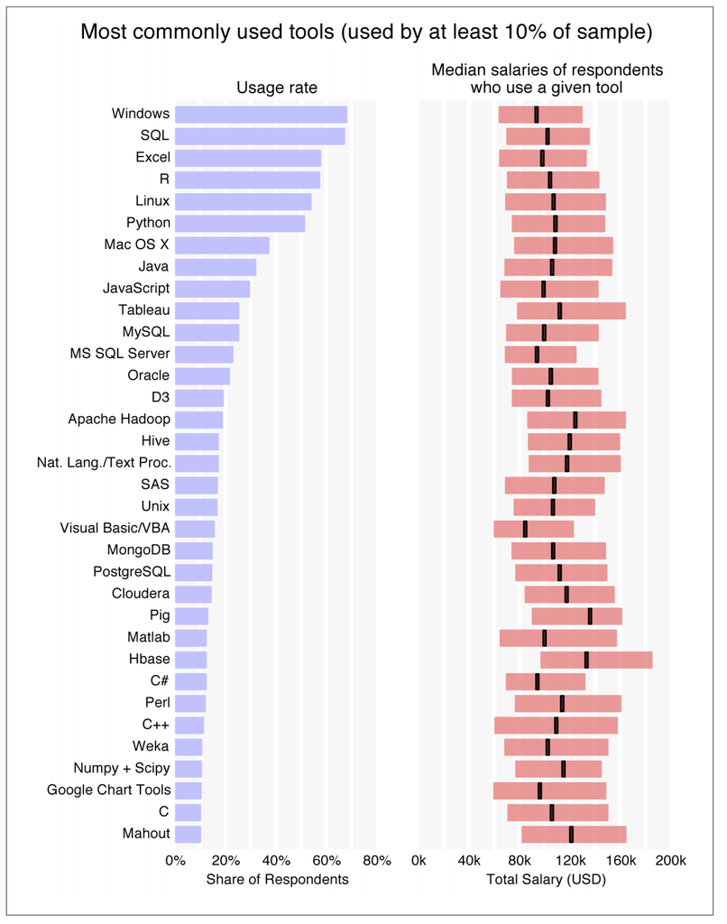

- More tools = higher pay

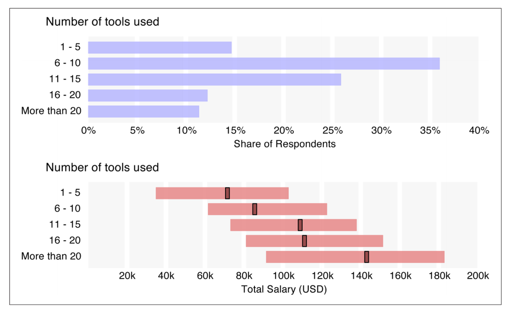

# Open source vs Proprietary tools

- This course will focus on the `R` statistical language
- Beyon `R` I will favor open-source tools
- However, the **right** tool is the **best** tool
- So cultivate a broad interest in analytical tools
- Job peak at the M.Sc.

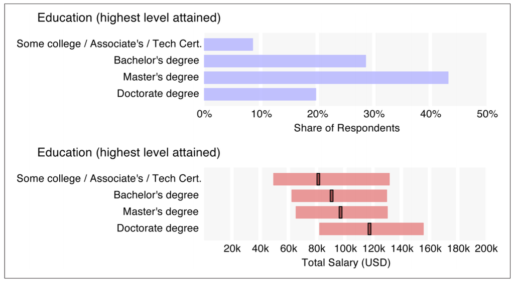

# What does an analyst do?

- Hard to define, broad synergist discipline.
- job function a product of organization, market sector, public or private industry, etc.
- review:http://www.datasciencecentral.com/profiles/blogs/17-analytic-disciplines-compared

# Introducing R

# R Languange

[figure not shown]

**Available from:** https://www.r-project.org/

# R History

- language & environment for statistical computing
- [GNU project](http://www.gnu.org/)
- Develped by Ross Ihaka and Robert Gentleman (Hence the name)
- Based on S from John Chambers at Bell Labs
- Essentially, S with *Lexical scoping*

# GNU

[figure not shown]

- GNU General Public License, written by [Richard Stallman](https://stallman.org) for [Emacs](https://www.gnu.org/software/emacs).
- Now most popular *free software license* [*](https://en.wikipedia.org/wiki/Free_software_license)
- OSS = Big user community = easier to learn

# Why R?

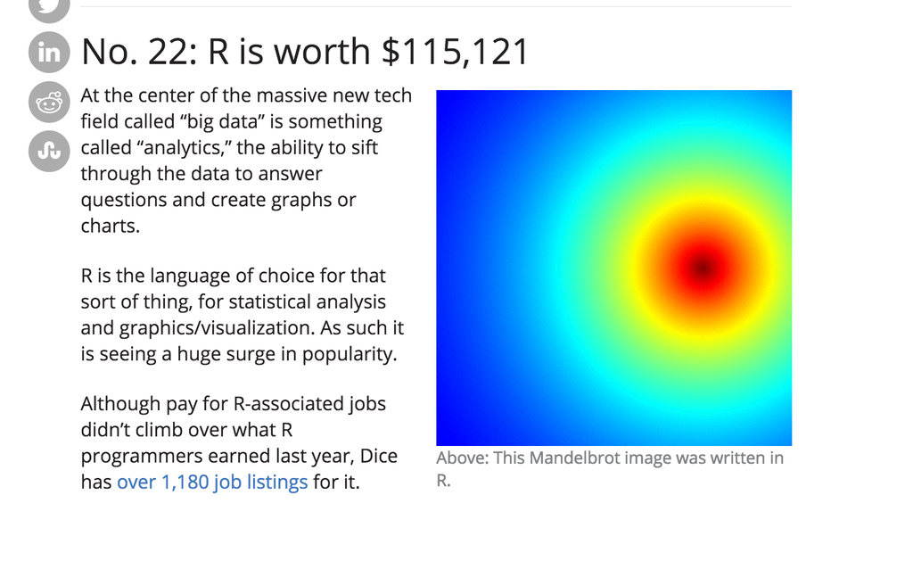

- Ranked by Venture Beat as on of the skills worth >$110,000

# Why R?

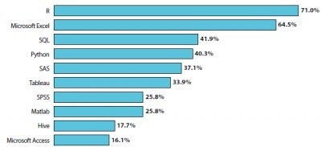

- Lavastorm Analytics 2014 Trends Report

# Getting R running

- install R: https://cran.rstudio.com/
- install Rstudio: https://www.rstudio.com/products/rstudio/download/
- Alternatives: Rgui, [Tinn-R](http://www.sciviews.org/Tinn-R/), [ESS](http://ess.r-project.org/), [Jupyter](https://jupyter.org/)
- Recent issue of JSS on R GUIs: http://www.jstatsoft.org/v49

# Testing R install

- Open RGUI, Rterm, or Rstudio and run

```
Sys.setenv(LC_COLLATE = "C", LANGUAGE = "en")
library("tools")
testInstalledBasic("both")
testInstalledPackages(scope = "base", errorsAreFatal = FALSE)
testInstalledPackages(scope = "recommended", errorsAreFatal = FALSE)
```

- some results in the `/R/home` directory find with `R.home()`

# Experiment

- R as a calculator

```r
2+2
```

```
## [1] 4
```

- a classic test

```r
print("hello world!")
```

```
## [1] "hello world!"
```

# Functions

```r
rnorm(15)
```

```
##  [1]  1.1072836  0.3295079  0.5522933  2.1030215  0.7816714  1.0420540
##  [7] -1.3471587 -1.5212314 -0.5329629 -0.9478708  1.5315744  0.4302314
## [13] -0.5291681  0.2426238  1.3963865
```

# Built-in functions in R

- `sum()` calculates sum
- `length()` calculates length of an object
- `sqrt()` calcs square root

# Functions build on themselves

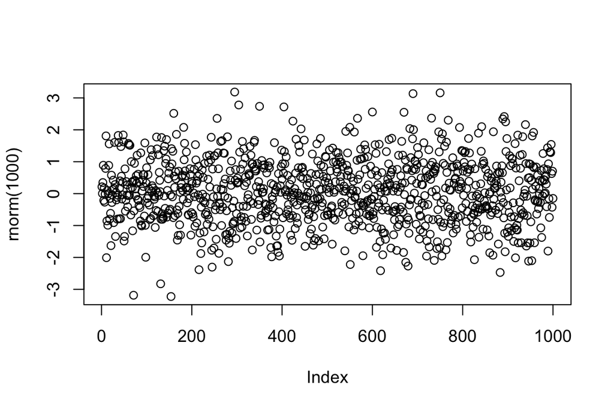

```r
plot(rnorm(1000))
```

Offering **lots** of statistical and graphical abilities.

# Assignments

- `R` uses *symbolic variables*, or names to represent values

```r
x <- 2

x + x
```

```
## [1] 4
```

# Naming variables

- names can be letters, digits, and the `.` or `_` symbols
- names **can not** start with a digit or a `.` then a digit
- Avoid names starting with a `.` they are special in `R`
- Typical names `dat`, `data.1`, `sales2010`, `sales.2010`
- names are **case sensitive** so `Sales2010` and `sales2010` are different
- Finally avoid `diff`, `df`, and `pt` as they exist within `R` for other purposes.

# Vectors

- a *vector* is a 1-dimensional **array**
- `R` literature and docs usually refer to 1D arrays as *vectors* rather than *n-tuple*
- *vectors* can be assigned a name and a value using the assingment operator show above

```r
weight <- c(60,72,57,90,95,72)
weight
```

```
## [1] 60 72 57 90 95 72
```

- we use the *construct* function `c(...)` to define the *vector*
- this is a quick method of data entry, we will examine many others!

# Vector math

- with additional vectors calculations can be made

```r
height <- c(1.75,1.80,1.65,1.90,1.74,1.91)
bmi <- weight/height^2
bmi
```

```
## [1] 19.59184 22.22222 20.93664 24.93075 31.37799 19.73630
```

- notice the use of the `^` operator for raising to a power
- Can `R` perform arithmatic operations on vectors of different lengths?

# Vector math

- **Yes** in this case `height^2` uses a vector lenght 6 with a single element vector
- single element vectors are `scalars`
- vectorized calculations are very easy and incredible useful in the world of “Big Data”

# Exercise

Calculate the mean and SD of the weight variable

# Solution

```r
# mean
xbar <- sum(weight)/length(weight)
xbar
```

```
## [1] 74.33333
```

```r
# std dev
sqrt(sum((weight - xbar)^2)/(length(weight)-1))
```

```
## [1] 15.42293
```

- `R` actually has already has these operations using `mean()` and `sd()`

```r
mean(weight)
```

```
## [1] 74.33333
```

```r
sd(weight)
```

```
## [1] 15.42293
```

# Statistical procedures

- recall we calculated `bmi`

```r
bmi
```

```
## [1] 19.59184 22.22222 20.93664 24.93075 31.37799 19.73630
```

- A “healthy” adult `bmi` ranges from 20-25
- How would we evalute the hypothesis that the `bmi` data has a mean of 22.5 assuming a normal distribution

# One sample t-test

- we can perform a quick t-test with the `t.test()` function

```r
t.test(bmi, mu=22.5)
```

```
##
##  One Sample t-test
##
## data:  bmi
## t = 0.34488, df = 5, p-value = 0.7442
## alternative hypothesis: true mean is not equal to 22.5
## 95 percent confidence interval:
##  18.41734 27.84791
## sample estimates:
## mean of x
##  23.13262
```

# R Graphics

# Powerful Graphics

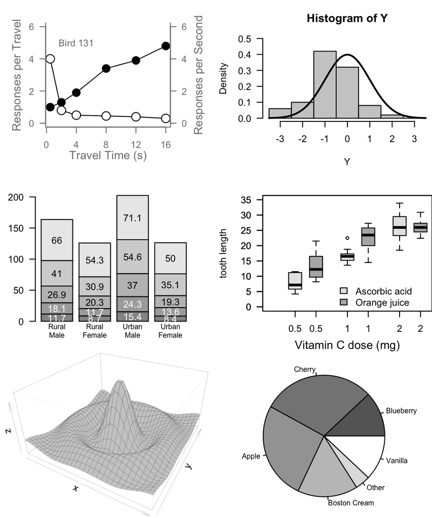

# Accidental aRt

http://accidental-art.tumblr.com/

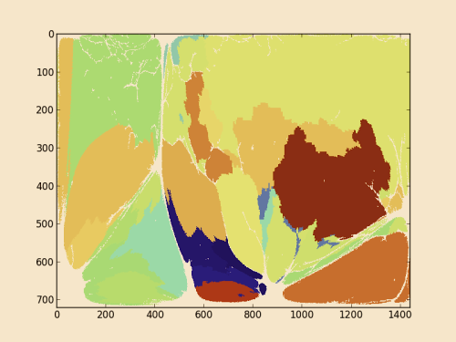

# Simple plotting

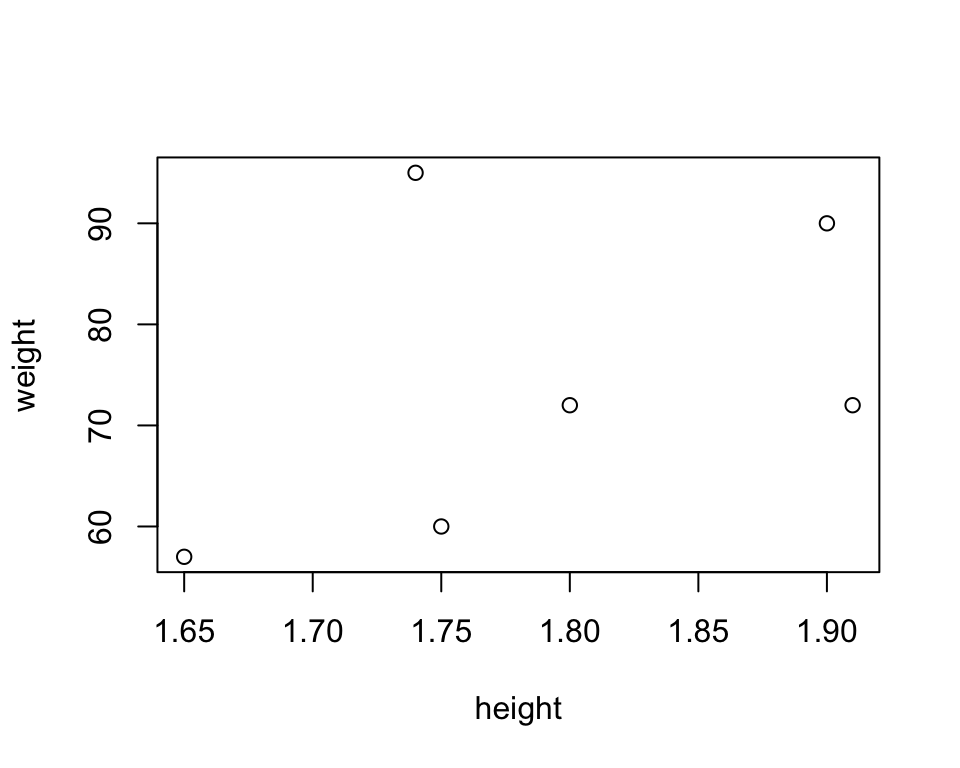

```r
plot(height, weight)
```

# Modifying plots

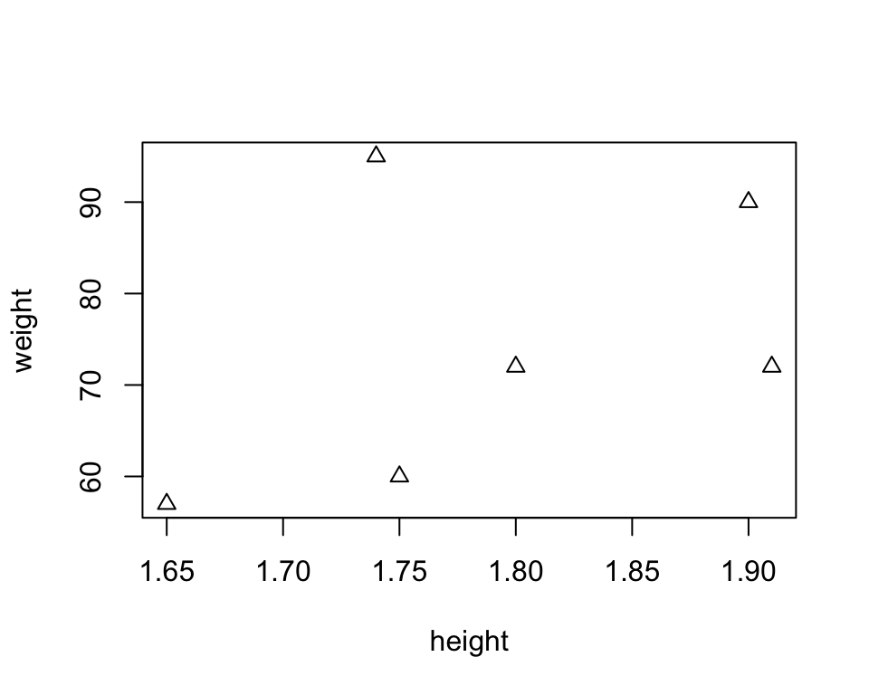

```r
plot(height, weight, pch=2)
```

- change symbols by altering the *plotting character* by selcting `pch`

# Further reading

http://www.statmethods.net/graphs/ http://shiny.stat.ubc.ca/r-graph-catalog/